# Price_prediction

## Predicting the price of the houses in Banglore, India

###### Dataset : https://www.kaggle.com/amitabhajoy/bengaluru-house-price-data

```python
# import packages

import pandas as pd
import numpy as np
from matplotlib import pyplot as plt
%matplotlib inline
import matplotlib
matplotlib.rcParams["figure.figsize"] = (20,10)
import warnings
warnings.filterwarnings('ignore') # supress warnings
import seaborn as sns
```

#### Data Loading

```python
# load the data

df1 = pd.read_csv("data/Bengaluru_House_Data.csv")
df1.head()
```

|  | area_type | availability | location | size | society | total_sqft | bath | balcony | price |
| --- | --- | --- | --- | --- | --- | --- | --- | --- | --- |
| 0 | Super built-up Area | 19-Dec | Electronic City Phase II | 2 BHK | Coomee | 1056 | 2.0 | 1.0 | 39.07 |
| 1 | Plot Area | Ready To Move | Chikka Tirupathi | 4 Bedroom | Theanmp | 2600 | 5.0 | 3.0 | 120.00 |
| 2 | Built-up Area | Ready To Move | Uttarahalli | 3 BHK | NaN | 1440 | 2.0 | 3.0 | 62.00 |
| 3 | Super built-up Area | Ready To Move | Lingadheeranahalli | 3 BHK | Soiewre | 1521 | 3.0 | 1.0 | 95.00 |
| 4 | Super built-up Area | Ready To Move | Kothanur | 2 BHK | NaN | 1200 | 2.0 | 1.0 | 51.00 |

```python
df1.shape
```

```
(13320, 9)
```

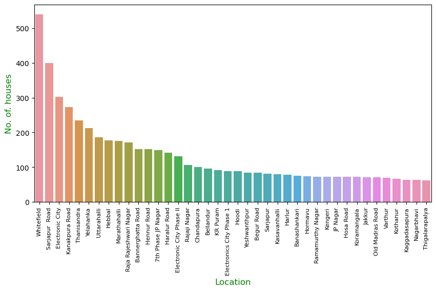

```python
plt.figure(figsize=(10,5))
most_cat = df1['location'].value_counts()[:40]
sns.barplot(x=most_cat.index, y=most_cat, data=df1)
plt.xticks(size=8, rotation=90)
plt.yticks(size=10)
plt.xlabel("Location",size=12,c="g")
plt.ylabel("No. of. houses",size=12,c="g")
plt.show()
```

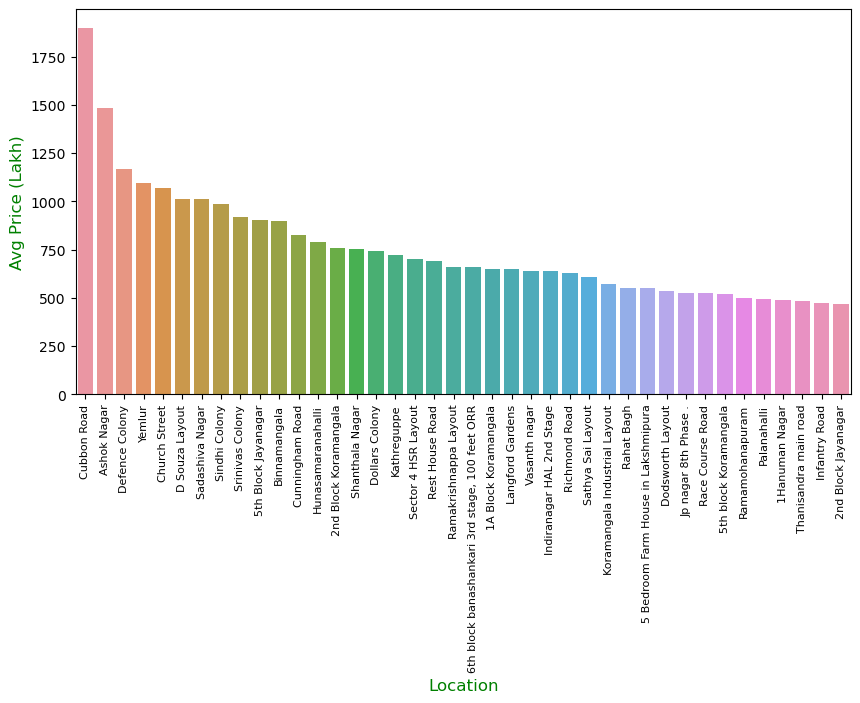

```python
plt.figure(figsize=(10,5))
avg_price_loc = df1.groupby('location')['price'].mean().sort_values(ascending=False)[:40]
sns.barplot(x=avg_price_loc.keys(), y=avg_price_loc)
plt.xticks(size=8, rotation=90)
plt.yticks(size=10)
plt.xlabel("Location",size=12,c="g")
plt.ylabel("Avg Price (Lakh)",size=12,c="g")
plt.show()
```

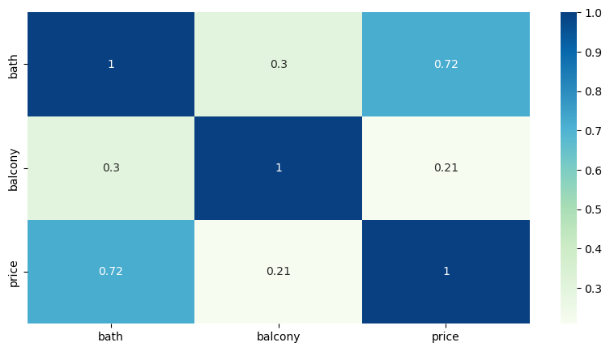

```python
plt.figure(figsize=(10, 5))
sns.heatmap(df1.corr(method='spearman'),
            annot=True, mask=None, cmap='GnBu')
plt.show()
```

##### We can drop the nominal features that can't be used to build our model. Refering to the heatmap, we can see 'balcony' has very low correlation with price, hence even 'balcony' can be dropped.

```python
# dropping non-useful features

df2 = df1.drop(['area_type','society','balcony','availability'],axis='columns')
df2.head()
```

|  | location | size | total_sqft | bath | price |
| --- | --- | --- | --- | --- | --- |
| 0 | Electronic City Phase II | 2 BHK | 1056 | 2.0 | 39.07 |
| 1 | Chikka Tirupathi | 4 Bedroom | 2600 | 5.0 | 120.00 |
| 2 | Uttarahalli | 3 BHK | 1440 | 2.0 | 62.00 |
| 3 | Lingadheeranahalli | 3 BHK | 1521 | 3.0 | 95.00 |
| 4 | Kothanur | 2 BHK | 1200 | 2.0 | 51.00 |

```python
df2.shape
```

```
(13320, 5)
```

#### Data Cleaning

```python
df2.isnull().sum()
```

```
location       1
size          16
total_sqft     0
bath          73
price          0
dtype: int64
```

```python
# clean the null/NA values

df3 = df2.dropna()
df3.isnull().sum()
```

```
location      0
size          0
total_sqft    0
bath          0
price         0
dtype: int64
```

#### Feature Engineering

##### The column 'size' has characters like BHK, Bedroom, etc. This needs to be handled such that the string data is converted into numeric data.

```python
df3['bhk'] = df3['size'].apply(lambda x: int(x.split(' ')[0])) # new column 'bhk' created with numeric data from 'size'
df3.bhk.unique()
```

```
array([ 2,  4,  3,  6,  1,  8,  7,  5, 11,  9, 27, 10, 19, 16, 43, 14, 12,
       13, 18])
```

##### The column 'total_sqft' has range values that can be converted to single numeric values by taking the average of the two bounds.

```python
def is_float(x):
    try:
        float(x)
    except:
        return False
    return True
```

```python
df3[~df3['total_sqft'].apply(is_float)].head(10)
```

|  | location | size | total_sqft | bath | price | bhk |
| --- | --- | --- | --- | --- | --- | --- |
| 30 | Yelahanka | 4 BHK | 2100 - 2850 | 4.0 | 186.000 | 4 |
| 122 | Hebbal | 4 BHK | 3067 - 8156 | 4.0 | 477.000 | 4 |
| 137 | 8th Phase JP Nagar | 2 BHK | 1042 - 1105 | 2.0 | 54.005 | 2 |
| 165 | Sarjapur | 2 BHK | 1145 - 1340 | 2.0 | 43.490 | 2 |
| 188 | KR Puram | 2 BHK | 1015 - 1540 | 2.0 | 56.800 | 2 |
| 410 | Kengeri | 1 BHK | 34.46Sq. Meter | 1.0 | 18.500 | 1 |
| 549 | Hennur Road | 2 BHK | 1195 - 1440 | 2.0 | 63.770 | 2 |
| 648 | Arekere | 9 Bedroom | 4125Perch | 9.0 | 265.000 | 9 |
| 661 | Yelahanka | 2 BHK | 1120 - 1145 | 2.0 | 48.130 | 2 |
| 672 | Bettahalsoor | 4 Bedroom | 3090 - 5002 | 4.0 | 445.000 | 4 |

```python
def convert_sqft_to_num(x):
    tokens = x.split('-')
    if len(tokens) == 2:
        return (float(tokens[0])+float(tokens[1]))/2
    try:
        return float(x)
    except:
        return None
```

```python
df4 = df3.copy()
df4.total_sqft = df4.total_sqft.apply(convert_sqft_to_num)
df4 = df4[df4.total_sqft.notnull()]
df4.head(2)
```

|  | location | size | total_sqft | bath | price | bhk |
| --- | --- | --- | --- | --- | --- | --- |
| 0 | Electronic City Phase II | 2 BHK | 1056.0 | 2.0 | 39.07 | 2 |
| 1 | Chikka Tirupathi | 4 Bedroom | 2600.0 | 5.0 | 120.00 | 4 |

```python
df3.loc[30]
```

```
location        Yelahanka
size                4 BHK
total_sqft    2100 - 2850
bath                  4.0
price               186.0
bhk                     4
Name: 30, dtype: object
```

```python
df4.loc[30]
```

```
location      Yelahanka
size              4 BHK
total_sqft       2475.0
bath                4.0
price             186.0
bhk                   4
Name: 30, dtype: object
```

##### We are creating a new column 'price_per_sqft' to detect outliers in our data.

```python
df5 = df4.copy()
df5['price_per_sqft'] = df5['price']*100000/df5['total_sqft']
df5.head()
```

|  | location | size | total_sqft | bath | price | bhk | price_per_sqft |
| --- | --- | --- | --- | --- | --- | --- | --- |
| 0 | Electronic City Phase II | 2 BHK | 1056.0 | 2.0 | 39.07 | 2 | 3699.810606 |
| 1 | Chikka Tirupathi | 4 Bedroom | 2600.0 | 5.0 | 120.00 | 4 | 4615.384615 |
| 2 | Uttarahalli | 3 BHK | 1440.0 | 2.0 | 62.00 | 3 | 4305.555556 |
| 3 | Lingadheeranahalli | 3 BHK | 1521.0 | 3.0 | 95.00 | 3 | 6245.890861 |
| 4 | Kothanur | 2 BHK | 1200.0 | 2.0 | 51.00 | 2 | 4250.000000 |

```python
df5.price_per_sqft.describe()
```

```
count    1.320000e+04
mean     7.920759e+03
std      1.067272e+05
min      2.678298e+02
25%      4.267701e+03
50%      5.438331e+03
75%      7.317073e+03
max      1.200000e+07
Name: price_per_sqft, dtype: float64
```

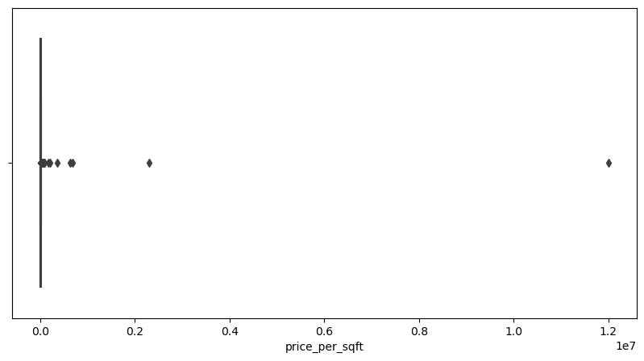

```python
plt.figure(figsize=(10, 5))
sns.boxplot(df5['price_per_sqft'])
plt.show()
```

##### We can strip these extreme values using the locations data

```python
len(df5.location.unique())
```

```
1298
```

```python
df5.location = df5.location.apply(lambda x: x.strip())
location_stats = df5['location'].value_counts(ascending=False)
location_stats
```

```
Whitefield                   533
Sarjapur  Road               392
Electronic City              304
Kanakpura Road               264
Thanisandra                  235
                            ...
Rajanna Layout                 1
Subramanyanagar                1
Lakshmipura Vidyaanyapura      1
Malur Hosur Road               1
Abshot Layout                  1
Name: location, Length: 1287, dtype: int64
```

##### The unique observations for locations is too high and this causes the dimensionality problem. We have to perform dimensionality reduction technique. So we tag any location having less than or equal to 10 data points as "other" location.

```python
len(location_stats[location_stats<=10])
```

```
1047
```

```python
location_stats_less_than_10 = location_stats[location_stats<=10]
location_stats_less_than_10
```

```
BTM 1st Stage                10
Gunjur Palya                 10
Nagappa Reddy Layout         10
Sector 1 HSR Layout          10
Thyagaraja Nagar             10
                             ..
Rajanna Layout                1
Subramanyanagar               1
Lakshmipura Vidyaanyapura     1
Malur Hosur Road              1
Abshot Layout                 1
Name: location, Length: 1047, dtype: int64
```

```python
df5.location = df5.location.apply(lambda x: 'other' if x in location_stats_less_than_10 else x)
len(df5.location.unique())
```

```
241
```

##### As per business logic, 1bhk can be built in minimumm 300sqft of area, so if the area is less than 300sqft then it is an anomaly and can be removed.

```python
df5[df5.total_sqft/df5.bhk<300].head()
```

|  | location | size | total_sqft | bath | price | bhk | price_per_sqft |
| --- | --- | --- | --- | --- | --- | --- | --- |
| 9 | other | 6 Bedroom | 1020.0 | 6.0 | 370.0 | 6 | 36274.509804 |
| 45 | HSR Layout | 8 Bedroom | 600.0 | 9.0 | 200.0 | 8 | 33333.333333 |
| 58 | Murugeshpalya | 6 Bedroom | 1407.0 | 4.0 | 150.0 | 6 | 10660.980810 |
| 68 | Devarachikkanahalli | 8 Bedroom | 1350.0 | 7.0 | 85.0 | 8 | 6296.296296 |
| 70 | other | 3 Bedroom | 500.0 | 3.0 | 100.0 | 3 | 20000.000000 |

```python
df5.shape
```

```
(13200, 7)
```

```python
df6 = df5[~(df5.total_sqft/df5.bhk<300)]
df6.shape
```

```
(12456, 7)
```

##### The box plot should look a little better now.

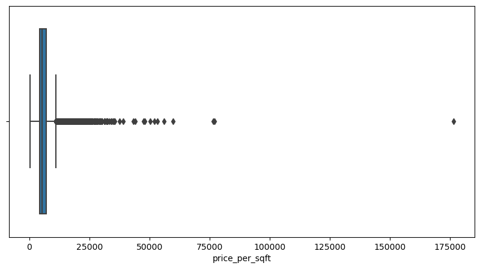

```python
plt.figure(figsize=(10, 5))
sns.boxplot(df6['price_per_sqft'])
plt.show()
```

```python
df6.price_per_sqft.describe()
```

```
count     12456.000000
mean       6308.502826
std        4168.127339
min         267.829813
25%        4210.526316
50%        5294.117647
75%        6916.666667
max      176470.588235
Name: price_per_sqft, dtype: float64
```

##### But we still see a huge difference between the min and the max value. We can use the logic that for a particular location the property prices of a area should lie within one standard deviation of the mean, to remove the outliers.

```python
def remove_pps_outliers(df):
    df_out = pd.DataFrame()
    for key, subdf in df.groupby('location'):
        m = np.mean(subdf.price_per_sqft)
        st = np.std(subdf.price_per_sqft)
        reduced_df = subdf[(subdf.price_per_sqft>(m-st)) & (subdf.price_per_sqft<=(m+st))]
        df_out = pd.concat([df_out,reduced_df],ignore_index=True)
    return df_out
```

```python
df7 = remove_pps_outliers(df6)
df7.shape
```

```
(10242, 7)
```

```python
# plotting the total area vs price chart for a particular location

def plot_scatter_chart(df,location):
    bhk2 = df[(df.location==location) & (df.bhk==2)]
    bhk3 = df[(df.location==location) & (df.bhk==3)]
    matplotlib.rcParams['figure.figsize'] = (15,10)
    plt.scatter(bhk2.total_sqft,bhk2.price,color='blue',label='2 BHK', s=50)
    plt.scatter(bhk3.total_sqft,bhk3.price,marker='+', color='green',label='3 BHK', s=50)
    plt.xlabel("Total Square Feet Area")
    plt.ylabel("Price (Lakh Indian Rupees)")
    plt.title(location)
    plt.legend()
```

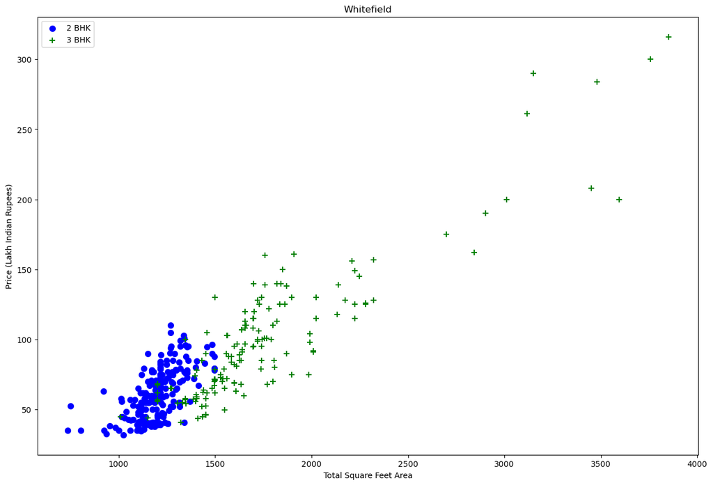

```python
plot_scatter_chart(df7,"Whitefield")
```

##### We see there is a lot of overlapping between the property prices of different sizes of the property in the same area. We can generically assume that larger houses will cost larger than the smaller houses, hence the price of the 2BHK house should be more than the mean of the 1BHK house. If not, its an outlier.

```python
def remove_bhk_outliers(df):
    exclude_indices = np.array([])
    for location, location_df in df.groupby('location'):
        bhk_stats = {}
        for bhk, bhk_df in location_df.groupby('bhk'):
            bhk_stats[bhk] = {
                'mean': np.mean(bhk_df.price_per_sqft),
                'std': np.std(bhk_df.price_per_sqft),
                'count': bhk_df.shape[0]
            }
        for bhk, bhk_df in location_df.groupby('bhk'):
            stats = bhk_stats.get(bhk-1)
            if stats and stats['count']>5:
                exclude_indices = np.append(exclude_indices, bhk_df[bhk_df.price_per_sqft<(stats['mean'])].index.values)
    return df.drop(exclude_indices,axis='index')
```

```python
df8 = remove_bhk_outliers(df7)
df8.shape
```

```
(7317, 7)
```

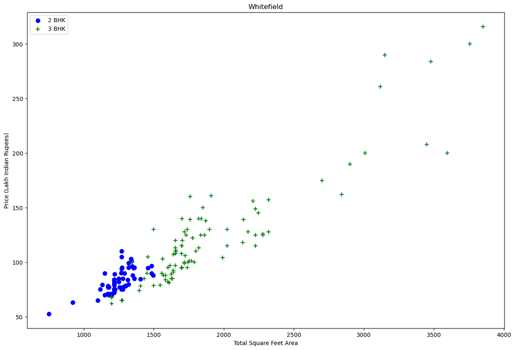

```python
plot_scatter_chart(df8,"Whitefield")
```

##### We will check the box plot again.

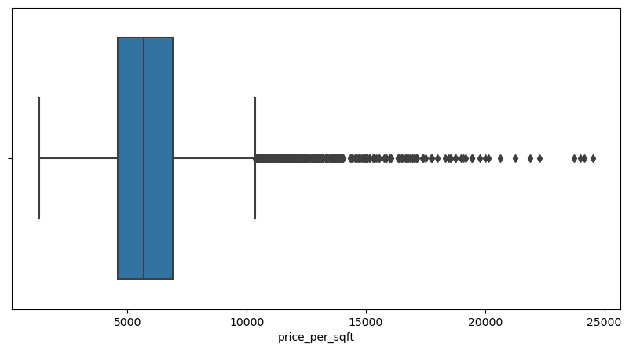

```python
plt.figure(figsize=(10, 5))
sns.boxplot(df8['price_per_sqft'])
plt.show()
```

```python
df8.price_per_sqft.describe()
```

```
count     7317.000000
mean      6126.119223
std       2410.348498
min       1300.000000
25%       4596.273292
50%       5681.818182
75%       6896.551724
max      24509.803922
Name: price_per_sqft, dtype: float64
```

##### We still have outliers, which is practically impossible to exclude. But we have successfully reduced the range of our data.

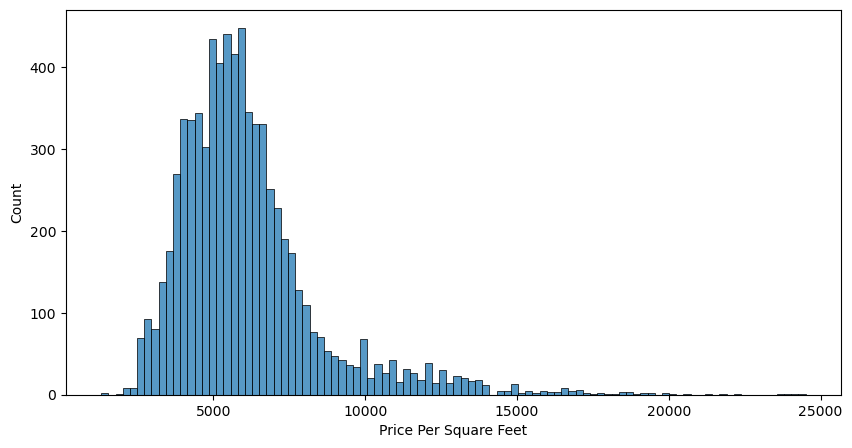

```python
# Histogram showing the normal distribution of our price data

plt.figure(figsize=(10, 5))
sns.histplot(df8.price_per_sqft)
plt.xlabel("Price Per Square Feet")
plt.ylabel("Count")
```

```python
df8['bath'].value_counts(ascending=False)
```

```
2.0     4188
3.0     1763
1.0      568
4.0      501
5.0      175
6.0       81
7.0       16
8.0       13
9.0        7
12.0       3
16.0       1
13.0       1
Name: bath, dtype: int64
```

```python
df8[df8.bath>10]
```

|  | location | size | total_sqft | bath | price | bhk | price_per_sqft |
| --- | --- | --- | --- | --- | --- | --- | --- |
| 5277 | Neeladri Nagar | 10 BHK | 4000.0 | 12.0 | 160.0 | 10 | 4000.000000 |
| 8483 | other | 10 BHK | 12000.0 | 12.0 | 525.0 | 10 | 4375.000000 |
| 8572 | other | 16 BHK | 10000.0 | 16.0 | 550.0 | 16 | 5500.000000 |
| 9306 | other | 11 BHK | 6000.0 | 12.0 | 150.0 | 11 | 2500.000000 |
| 9637 | other | 13 BHK | 5425.0 | 13.0 | 275.0 | 13 | 5069.124424 |

##### Exploring the column 'bath'. It is unusual to have more bathrooms than bedrooms. But we would consider here, no. of. bathrooms = no. of. bedrooms + 1, anything over this is an outlier.

```python
df8[df8.bath>=df8.bhk+2]
```

|  | location | size | total_sqft | bath | price | bhk | price_per_sqft |
| --- | --- | --- | --- | --- | --- | --- | --- |
| 36 | 2nd Stage Nagarbhavi | 6 Bedroom | 3000.0 | 8.0 | 451.0 | 6 | 15033.333333 |
| 37 | 2nd Stage Nagarbhavi | 6 Bedroom | 2400.0 | 8.0 | 450.0 | 6 | 18750.000000 |
| 530 | Arekere | 4 BHK | 2710.0 | 6.0 | 142.0 | 4 | 5239.852399 |
| 580 | BTM 2nd Stage | 3 Bedroom | 1260.0 | 5.0 | 185.0 | 3 | 14682.539683 |
| 813 | Bannerghatta | 4 BHK | 3012.0 | 6.0 | 250.0 | 4 | 8300.132802 |
| ... | ... | ... | ... | ... | ... | ... | ... |
| 9914 | other | 4 BHK | 6652.0 | 6.0 | 510.0 | 4 | 7666.867108 |
| 10035 | other | 2 BHK | 600.0 | 4.0 | 70.0 | 2 | 11666.666667 |
| 10090 | other | 3 Bedroom | 5656.0 | 5.0 | 499.0 | 3 | 8822.489392 |
| 10203 | other | 4 BHK | 6652.0 | 6.0 | 660.0 | 4 | 9921.828022 |
| 10210 | other | 4 Bedroom | 6688.0 | 6.0 | 700.0 | 4 | 10466.507177 |

78 rows × 7 columns

```python
df9 = df8[df8.bath<df8.bhk+2]
df9.shape
```

```
(7239, 7)
```

##### Outlier removal done, we can drop the extra columns created.

```python
df10 = df9.drop(['size','price_per_sqft'],axis='columns')
df10.head()
```

|  | location | total_sqft | bath | price | bhk |
| --- | --- | --- | --- | --- | --- |
| 0 | 1st Block Jayanagar | 2850.0 | 4.0 | 428.0 | 4 |
| 1 | 1st Block Jayanagar | 1630.0 | 3.0 | 194.0 | 3 |
| 2 | 1st Block Jayanagar | 1875.0 | 2.0 | 235.0 | 3 |
| 3 | 1st Block Jayanagar | 1200.0 | 2.0 | 130.0 | 3 |
| 4 | 1st Block Jayanagar | 1235.0 | 2.0 | 148.0 | 2 |

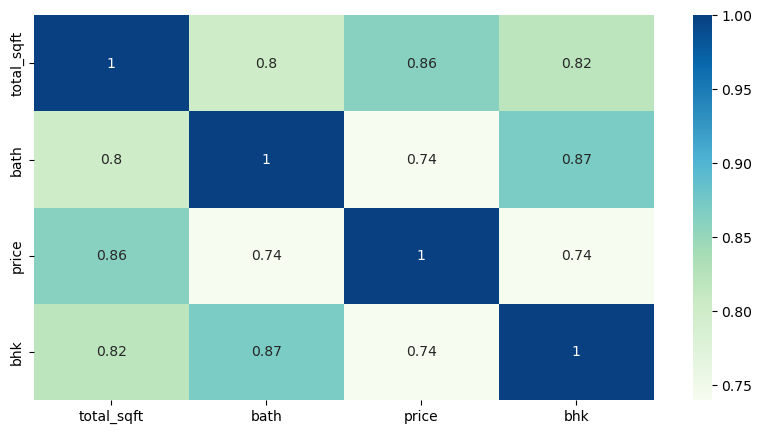

```python
plt.figure(figsize=(10, 5))
sns.heatmap(round(df10.corr(method='spearman'), 2),
            annot=True, mask=None, cmap='GnBu')
plt.show()
```

##### We see strong correlation between all the features we have selected.

#### One-hot encoding for the categorical 'location' data

```python
len(df10.location.unique())
```

```
241
```

```python
loc_dummies = pd.get_dummies(df10.location)
loc_dummies.head()
```

|  | 1st Block Jayanagar | 1st Phase JP Nagar | 2nd Phase Judicial Layout | 2nd Stage Nagarbhavi | 5th Block Hbr Layout | 5th Phase JP Nagar | 6th Phase JP Nagar | 7th Phase JP Nagar | 8th Phase JP Nagar | 9th Phase JP Nagar | ... | Vishveshwarya Layout | Vishwapriya Layout | Vittasandra | Whitefield | Yelachenahalli | Yelahanka | Yelahanka New Town | Yelenahalli | Yeshwanthpur | other |
| --- | --- | --- | --- | --- | --- | --- | --- | --- | --- | --- | --- | --- | --- | --- | --- | --- | --- | --- | --- | --- | --- |
| 0 | 1 | 0 | 0 | 0 | 0 | 0 | 0 | 0 | 0 | 0 | ... | 0 | 0 | 0 | 0 | 0 | 0 | 0 | 0 | 0 | 0 |
| 1 | 1 | 0 | 0 | 0 | 0 | 0 | 0 | 0 | 0 | 0 | ... | 0 | 0 | 0 | 0 | 0 | 0 | 0 | 0 | 0 | 0 |
| 2 | 1 | 0 | 0 | 0 | 0 | 0 | 0 | 0 | 0 | 0 | ... | 0 | 0 | 0 | 0 | 0 | 0 | 0 | 0 | 0 | 0 |
| 3 | 1 | 0 | 0 | 0 | 0 | 0 | 0 | 0 | 0 | 0 | ... | 0 | 0 | 0 | 0 | 0 | 0 | 0 | 0 | 0 | 0 |
| 4 | 1 | 0 | 0 | 0 | 0 | 0 | 0 | 0 | 0 | 0 | ... | 0 | 0 | 0 | 0 | 0 | 0 | 0 | 0 | 0 | 0 |

5 rows × 241 columns

```python
df11 = pd.concat([df10,loc_dummies.drop('other',axis='columns')],axis='columns')
df11.head()
```

|  | location | total_sqft | bath | price | bhk | 1st Block Jayanagar | 1st Phase JP Nagar | 2nd Phase Judicial Layout | 2nd Stage Nagarbhavi | 5th Block Hbr Layout | ... | Vijayanagar | Vishveshwarya Layout | Vishwapriya Layout | Vittasandra | Whitefield | Yelachenahalli | Yelahanka | Yelahanka New Town | Yelenahalli | Yeshwanthpur |
| --- | --- | --- | --- | --- | --- | --- | --- | --- | --- | --- | --- | --- | --- | --- | --- | --- | --- | --- | --- | --- | --- |
| 0 | 1st Block Jayanagar | 2850.0 | 4.0 | 428.0 | 4 | 1 | 0 | 0 | 0 | 0 | ... | 0 | 0 | 0 | 0 | 0 | 0 | 0 | 0 | 0 | 0 |
| 1 | 1st Block Jayanagar | 1630.0 | 3.0 | 194.0 | 3 | 1 | 0 | 0 | 0 | 0 | ... | 0 | 0 | 0 | 0 | 0 | 0 | 0 | 0 | 0 | 0 |
| 2 | 1st Block Jayanagar | 1875.0 | 2.0 | 235.0 | 3 | 1 | 0 | 0 | 0 | 0 | ... | 0 | 0 | 0 | 0 | 0 | 0 | 0 | 0 | 0 | 0 |
| 3 | 1st Block Jayanagar | 1200.0 | 2.0 | 130.0 | 3 | 1 | 0 | 0 | 0 | 0 | ... | 0 | 0 | 0 | 0 | 0 | 0 | 0 | 0 | 0 | 0 |
| 4 | 1st Block Jayanagar | 1235.0 | 2.0 | 148.0 | 2 | 1 | 0 | 0 | 0 | 0 | ... | 0 | 0 | 0 | 0 | 0 | 0 | 0 | 0 | 0 | 0 |

5 rows × 245 columns

```python
df12 = df11.drop('location',axis='columns')
df12.head()
```

|  | total_sqft | bath | price | bhk | 1st Block Jayanagar | 1st Phase JP Nagar | 2nd Phase Judicial Layout | 2nd Stage Nagarbhavi | 5th Block Hbr Layout | 5th Phase JP Nagar | ... | Vijayanagar | Vishveshwarya Layout | Vishwapriya Layout | Vittasandra | Whitefield | Yelachenahalli | Yelahanka | Yelahanka New Town | Yelenahalli | Yeshwanthpur |
| --- | --- | --- | --- | --- | --- | --- | --- | --- | --- | --- | --- | --- | --- | --- | --- | --- | --- | --- | --- | --- | --- |
| 0 | 2850.0 | 4.0 | 428.0 | 4 | 1 | 0 | 0 | 0 | 0 | 0 | ... | 0 | 0 | 0 | 0 | 0 | 0 | 0 | 0 | 0 | 0 |
| 1 | 1630.0 | 3.0 | 194.0 | 3 | 1 | 0 | 0 | 0 | 0 | 0 | ... | 0 | 0 | 0 | 0 | 0 | 0 | 0 | 0 | 0 | 0 |
| 2 | 1875.0 | 2.0 | 235.0 | 3 | 1 | 0 | 0 | 0 | 0 | 0 | ... | 0 | 0 | 0 | 0 | 0 | 0 | 0 | 0 | 0 | 0 |
| 3 | 1200.0 | 2.0 | 130.0 | 3 | 1 | 0 | 0 | 0 | 0 | 0 | ... | 0 | 0 | 0 | 0 | 0 | 0 | 0 | 0 | 0 | 0 |
| 4 | 1235.0 | 2.0 | 148.0 | 2 | 1 | 0 | 0 | 0 | 0 | 0 | ... | 0 | 0 | 0 | 0 | 0 | 0 | 0 | 0 | 0 | 0 |

5 rows × 244 columns

```python
df12.shape
```

```
(7239, 244)
```

#### Building a model

```python
# independent variable X

X = df12.drop(['price'],axis='columns')
X.head()
```

|  | total_sqft | bath | bhk | 1st Block Jayanagar | 1st Phase JP Nagar | 2nd Phase Judicial Layout | 2nd Stage Nagarbhavi | 5th Block Hbr Layout | 5th Phase JP Nagar | 6th Phase JP Nagar | ... | Vijayanagar | Vishveshwarya Layout | Vishwapriya Layout | Vittasandra | Whitefield | Yelachenahalli | Yelahanka | Yelahanka New Town | Yelenahalli | Yeshwanthpur |
| --- | --- | --- | --- | --- | --- | --- | --- | --- | --- | --- | --- | --- | --- | --- | --- | --- | --- | --- | --- | --- | --- |
| 0 | 2850.0 | 4.0 | 4 | 1 | 0 | 0 | 0 | 0 | 0 | 0 | ... | 0 | 0 | 0 | 0 | 0 | 0 | 0 | 0 | 0 | 0 |
| 1 | 1630.0 | 3.0 | 3 | 1 | 0 | 0 | 0 | 0 | 0 | 0 | ... | 0 | 0 | 0 | 0 | 0 | 0 | 0 | 0 | 0 | 0 |
| 2 | 1875.0 | 2.0 | 3 | 1 | 0 | 0 | 0 | 0 | 0 | 0 | ... | 0 | 0 | 0 | 0 | 0 | 0 | 0 | 0 | 0 | 0 |
| 3 | 1200.0 | 2.0 | 3 | 1 | 0 | 0 | 0 | 0 | 0 | 0 | ... | 0 | 0 | 0 | 0 | 0 | 0 | 0 | 0 | 0 | 0 |
| 4 | 1235.0 | 2.0 | 2 | 1 | 0 | 0 | 0 | 0 | 0 | 0 | ... | 0 | 0 | 0 | 0 | 0 | 0 | 0 | 0 | 0 | 0 |

5 rows × 243 columns

```python
X.shape
```

```
(7239, 243)
```

```python
# dependent variable y

y = df12.price
y.head()
```

```
0    428.0
1    194.0
2    235.0
3    130.0
4    148.0
Name: price, dtype: float64
```

```python
len(y)
```

```
7239
```

```python
# Using GridSearchCV to determine the best regression models

from sklearn.linear_model import LinearRegression
from sklearn.model_selection import GridSearchCV
from sklearn.linear_model import Lasso
from sklearn.linear_model import Ridge
from sklearn.tree import DecisionTreeRegressor
from sklearn.ensemble import RandomForestRegressor
from sklearn.model_selection import ShuffleSplit

def find_best_model_using_gridsearchcv(X,y):
    algos = {
        'linear_regression' : {
            'model': LinearRegression(),
            'params': {
                'normalize': [True, False]
            }
        },
        'lasso': {
            'model': Lasso(),
            'params': {
                'alpha': [1, 2],
                'selection': ['random', 'cyclic']
           }
        },
        'ridge': {
            'model': Ridge(),
            'params': {
                'alpha': [1, 2]
           }
        },
        'decision_tree': {
            'model': DecisionTreeRegressor(),
            'params': {
                'criterion' : ['mse','friedman_mse'],
                'splitter': ['best','random']
            }
        },
        'random_forest': {
            'model': RandomForestRegressor(),
            'params': {
            }
        }
    }
    scores = []
    cv = ShuffleSplit(n_splits=5, test_size=0.2, random_state=0)
    for algo_name, config in algos.items():
        gs =  GridSearchCV(config['model'], config['params'], cv=cv, return_train_score=False)
        gs.fit(X,y)
        scores.append({
            'model': algo_name,
            'best_score': gs.best_score_,
            'best_params': gs.best_params_
        })

    return pd.DataFrame(scores,columns=['model','best_score','best_params'])
```

```python
find_best_model_using_gridsearchcv(X,y)
```

|  | model | best_score | best_params |
| --- | --- | --- | --- |
| 0 | linear_regression | 0.847796 | {'normalize': False} |
| 1 | lasso | 0.726838 | {'alpha': 2, 'selection': 'random'} |
| 2 | ridge | 0.846798 | {'alpha': 1} |
| 3 | decision_tree | 0.741722 | {'criterion': 'mse', 'splitter': 'random'} |
| 4 | random_forest | 0.778779 | {} |

```python
from sklearn.model_selection import train_test_split
X_train, X_test, y_train, y_test = train_test_split(X,y,test_size=0.2,random_state=10)
```

```python
from sklearn.model_selection import cross_val_score

cv = ShuffleSplit(n_splits=5, test_size=0.2, random_state=0)
cross_val_score(LinearRegression(), X, y, cv=cv)
```

```
array([0.82702546, 0.86027005, 0.85322178, 0.8436466 , 0.85481502])
```

```python
cross_val_score(RandomForestRegressor(), X, y, cv=cv)
```

```
array([0.85198374, 0.84694065, 0.76910398, 0.62934662, 0.8352014 ])
```

```python
from math import sqrt
from sklearn.metrics import r2_score
from sklearn.metrics import mean_squared_error, mean_absolute_error

def model_metrics(model, X_test, y_test):
    model_prediction=model.predict(X_test)
    print('R2 Score :',r2_score(model_prediction,y_test)*100)
    print('MAE:',mean_absolute_error(model_prediction,y_test))
    print('MSE:',mean_squared_error(model_prediction,y_test))
    rmse = sqrt(mean_squared_error(model_prediction,y_test))
    print('RMSE:',rmse)

    return model.score(X_test,y_test)
```

```python
lr_clf = LinearRegression()
lr_clf.fit(X_train,y_train)
model_metrics(lr_clf, X_test, y_test)
```

```
R2 Score : 85.19741195607283
MAE: 16.155431156699287
MSE: 711.056385851803
RMSE: 26.66564054831241
```

```
0.8629132245229449
```

```python
rf_clf = RandomForestRegressor()
rf_clf.fit(X_train, y_train)
model_metrics(rf_clf, X_test, y_test)
```

```
R2 Score : 76.22754030834919
MAE: 18.398773987557515
MSE: 1161.1531385186988
RMSE: 34.07569718316412
```

```
0.7761376695831175
```

```python
def predict_price(location,sqft,bath,bhk):
    loc_index = np.where(X.columns==location)[0][0]

    x = np.zeros(len(X.columns))
    x[0] = sqft
    x[1] = bath
    x[2] = bhk
    if loc_index >= 0:
        x[loc_index] = 1

    return lr_clf.predict([x])[0]
```

```python
predict_price('1st Phase JP Nagar',1000, 2, 2)
```

```
83.86570258311195
```

```python
predict_price('1st Phase JP Nagar',1000, 3, 3)
```

```
86.08062284985971
```

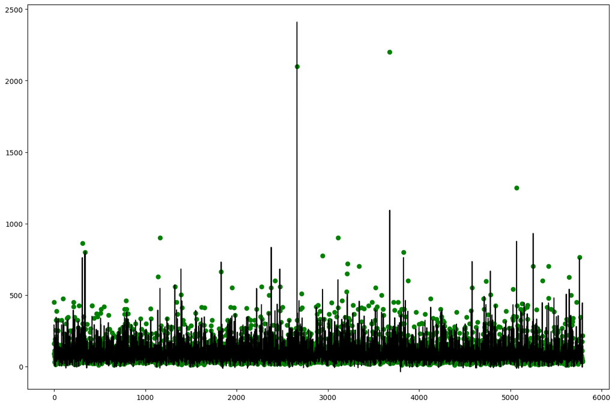

```python
plt.scatter(np.arange(0,len(X_train),1), y_train,color='g')
plt.plot(np.arange(0,len(X_train),1), lr_clf.predict(X_train),color='k')
```

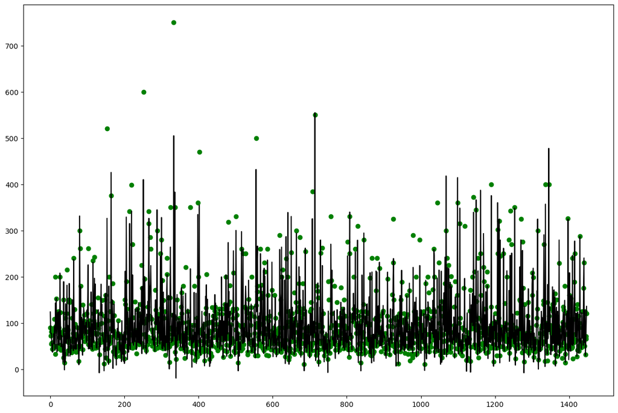

```python
plt.scatter(np.arange(0,len(X_test),1), y_test,color='g')
plt.plot(np.arange(0,len(X_test),1), lr_clf.predict(X_test),color='k')
```

##### Export the model for sharing

```python
import pickle
with open('banglore_home_prices_model.pickle','wb') as f:
    pickle.dump(lr_clf,f)
```

```python
import json
columns = {
    'data_columns' : [col.lower() for col in X.columns]
}
with open("columns.json","w") as f:
    f.write(json.dumps(columns))
```